# Boas práticas em análises de séries temporais em herpetologia

Karoline Ceron, Marcos R. Severgnini e Diogo B. Provete

28/10/2020

Vamos iniciar carregando os pacotes necessários! Caso você não os tenha instalados, instale-os com a função *install.packages(“nome do pacote”)* e depois carregue-os.

```r
knitr::opts_chunk$set(warning = FALSE, message = FALSE, error=FALSE)
install.packages("AEM", repos="http://R-Forge.R-project.org")
library(GGally)
library(nlme)
library(mgcv)
library(tidyverse)
library(lmtest)
library(bbmle)
library(tseries)
library(astsa)
library(circular)
library(adespatial)
library(ade4)
```

```r
library(adegraphics)
library(expsmooth)
library(vegan)
library(AEM)
```

# MODELOS DE PREVISÃO

## ARIMA

Vamos carregar a planilha *bonds* do pacote *expsmooth* que indica os rendimentos mensais de títulos do governo dos EUA. Aqui vamos considerar estes dados como sendo a abundância relativa de girinos em uma poça permanente.

```r
gir<-bonds
```

Agora vamos visualizar os dados e decompô-los

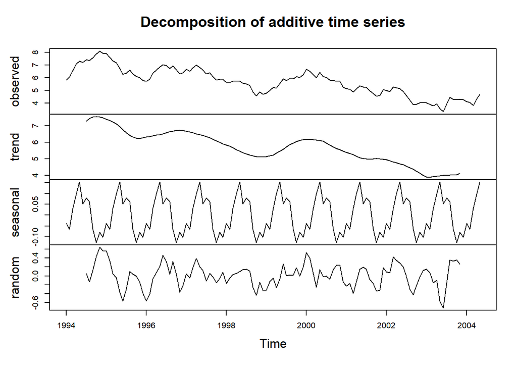

```r
plot(decompose(gir))
```

Observe o padrão sazonal cíclico apresentado na figura

Existe uma função no R para verificar o número de diferenças necessárias para transformar uma série temporal em estacionária.

```r
ndiffs(gir)
```

```
## [1] 1
```

Os métodos usados para testar a estacionariedade em cada etapa são - o teste de Dickey-Fuller aumentado, o teste de raiz unitária Phillips-Perron e o teste de estacionariedade KPSS.

```r
adf.test(gir); pp.test(gir); kpss.test(gir)
```

```
##
##  Augmented Dickey-Fuller Test
##
## data:  gir
## Dickey-Fuller = -3.409, Lag order = 4, p-value = 0.05631
## alternative hypothesis: stationary
```

```
##
##  Phillips-Perron Unit Root Test
##
## data:  gir
## Dickey-Fuller Z(alpha) = -22.192, Truncation lag parameter = 4, p-value
## = 0.0381
## alternative hypothesis: stationary
```

```
##
##  KPSS Test for Level Stationarity
##
## data:  gir
## KPSS Level = 1.9649, Truncation lag parameter = 4, p-value = 0.01
```

Note que a hipótese alternativa do teste ADF e do PP é a estacionaridade, ao contrário do teste KPSS. A partir disso não podemos concluir que nossos dados são estacionários.

Vamos tentar diferenciar nossos dados

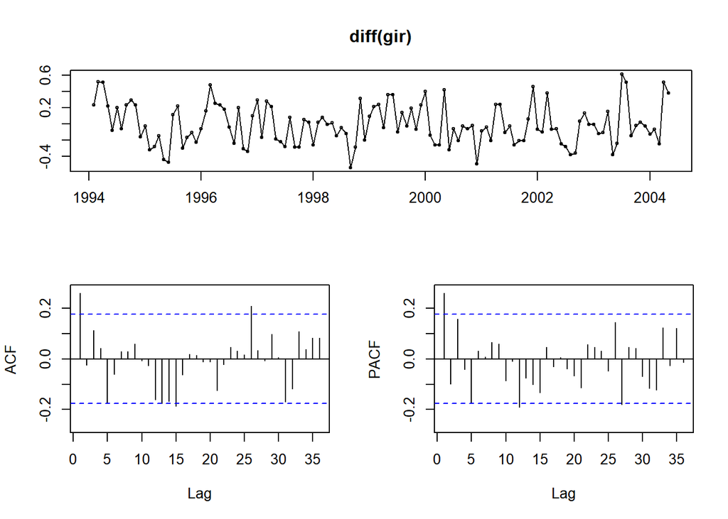

```r
tsdisplay(diff(gir))
```

A sazonalidade pode ser identificada nas séries diferenciadas - evidentes na ACF. A série residual parece ter uma variação semelhante ao longo do tempo (PACF). Contudo, a sazonalidade ainda é aparente na ACF. Portanto, precisamos removê-la dos dados

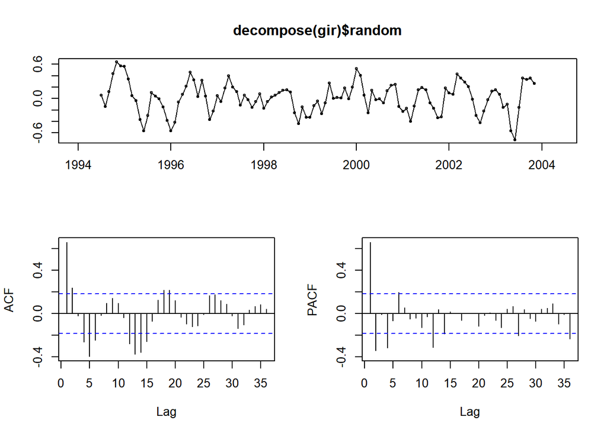

```r
tsdisplay(decompose(gir)$random)
```

Melhorou bastante, mas talvez ainda apresente alguns vestígios de sazonalidade.

Agora vamos encontrar um modelo adequado aos nossos dados

```r
arimaModel <- auto.arima(gir)
summary(arimaModel)
```

```
## Series: gir
## ARIMA(0,1,1)(1,0,0)[12]
##
## Coefficients:
##          ma1     sar1
##       0.3125  -0.1558
## s.e.  0.0920   0.0963
##
## sigma^2 estimated as 0.05591:  log likelihood=3.67
## AIC=-1.34   AICc=-1.14   BIC=7.12
##
## Training set error measures:
##                        ME      RMSE       MAE        MPE     MAPE      MASE
## Training set -0.008924502 0.2335975 0.1907936 -0.2579651 3.494866 0.2363741
##                     ACF1
## Training set -0.02463907
```

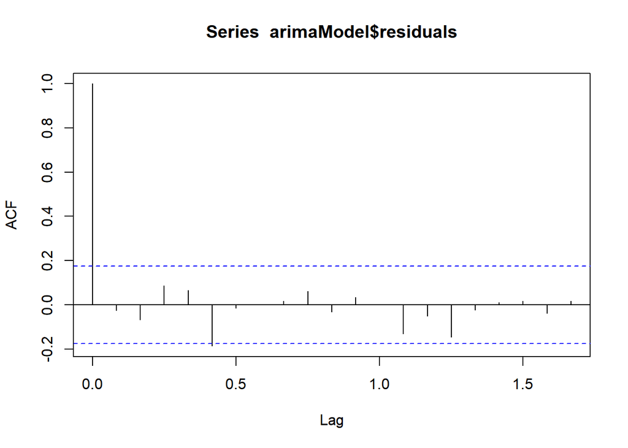

```r
acf(arimaModel$residuals)
```

A ACF dos resíduos do modelo mostra que a maior parte das autocorrelações estão dentro dos limites indicando que os resíduos não apresentam autocorrelação serial.

Agora vamos fazer a previsão

```r
fcast <- forecast(arimaModel)
```

Criando o gráfico de previsão

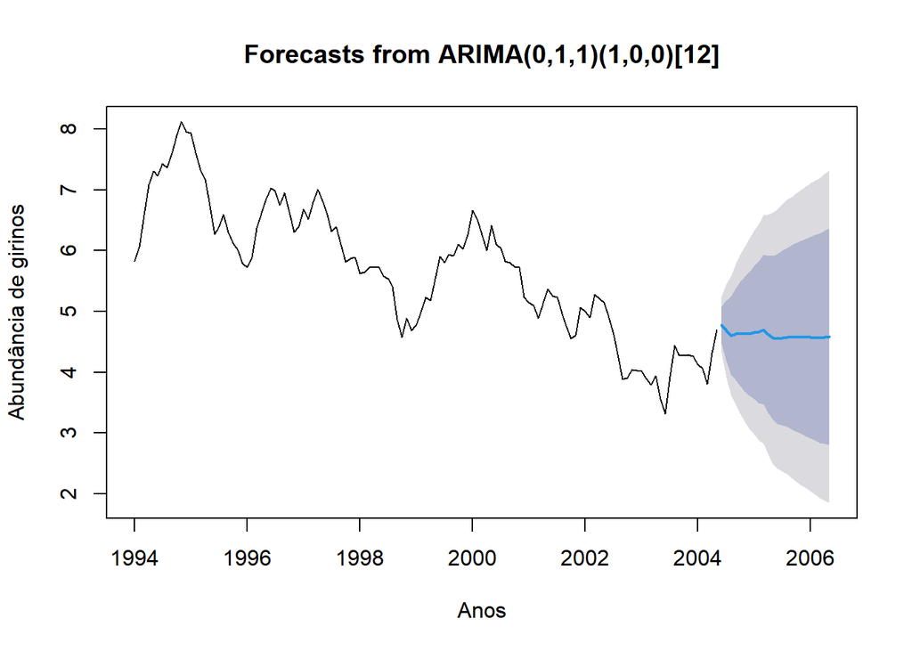

```r
plot(fcast, ylab="Abundância de girinos", xlab="Anos")
```

Aqui está a previsão para os anos seguintes, onde a parte em azul reflete os intervalos de previsão de 80% e 95%.

Resultado do modelo

```r
summary(fcast)
```

```
##
## Forecast method: ARIMA(0,1,1)(1,0,0)[12]
##
## Model Information:
## Series: gir
## ARIMA(0,1,1)(1,0,0)[12]
##
## Coefficients:
##          ma1     sar1
##       0.3125  -0.1558
## s.e.  0.0920   0.0963
##
## sigma^2 estimated as 0.05591:  log likelihood=3.67
## AIC=-1.34   AICc=-1.14   BIC=7.12
##
## Error measures:
##                        ME      RMSE       MAE        MPE     MAPE      MASE
## Training set -0.008924502 0.2335975 0.1907936 -0.2579651 3.494866 0.2363741
##                     ACF1
## Training set -0.02463907
##
## Forecasts:
##          Point Forecast    Lo 80    Hi 80    Lo 95    Hi 95
## Jun 2004       4.777891 4.474865 5.080916 4.314453 5.241328
## Jul 2004       4.682865 4.182867 5.182863 3.918184 5.447546
## Aug 2004       4.603418 3.964535 5.242300 3.626331 5.580504
## Sep 2004       4.626785 3.874226 5.379343 3.475845 5.777724
## Oct 2004       4.629900 3.778714 5.481086 3.328123 5.931677
## Nov 2004       4.626785 3.687268 5.566301 3.189918 6.063651
## Dec 2004       4.631458 3.611230 5.651686 3.071154 6.191761
## Jan 2005       4.651709 3.556703 5.746715 2.977042 6.326376
## Feb 2005       4.662614 3.497620 5.827608 2.880909 6.444318
## Mar 2005       4.701559 3.470549 5.932568 2.818892 6.584225
## Apr 2005       4.622111 3.328451 5.915772 2.643628 6.600594
## May 2005       4.562915 3.209500 5.916330 2.493046 6.632784
## Jun 2005       4.550781 3.152717 5.948846 2.412626 6.688937
## Jul 2005       4.565584 3.127768 6.003401 2.366634 6.764535
## Aug 2005       4.577961 3.101462 6.054459 2.319851 6.836070
## Sep 2005       4.574320 3.060128 6.088513 2.258563 6.890078
## Oct 2005       4.573835 3.022864 6.124806 2.201830 6.945840
## Nov 2005       4.574320 2.987423 6.161217 2.147371 7.001270
## Dec 2005       4.573592 2.951565 6.195620 2.092915 7.054270
## Jan 2006       4.570438 2.914024 6.226851 2.037172 7.103703
## Feb 2006       4.568739 2.878639 6.258839 1.983955 7.153523
## Mar 2006       4.562672 2.839545 6.285800 1.927376 7.197968
## Apr 2006       4.575048 2.819514 6.330582 1.890191 7.259906
## May 2006       4.584270 2.796917 6.371623 1.850749 7.317791
```

## ARIMA com sazonalidade = SARIMA

Vamos iniciar criando um vetor hipotetico para riqueza de anuros em uma comunidade

```r
sp_vector <- c(19,19,19,27,20,9,10,9,3,1,2,1,1,11,19,19,19,27,20,20,6,5,2,1,2,9,9,11,19,19,9,8,8,5,1,3,8,9,10,9,12,11,7,5,5,4,2,2,7,10,8,10,19,20,7,5)
```

Indicando que a série temporal inicia em Setembro (9) de 2014 e tem frequência de 12 meses

```r
sp_ts <- ts(sp_vector,start=c(2014,9),frequency=12)
sp_ts
```

```
##      Jan Feb Mar Apr May Jun Jul Aug Sep Oct Nov Dec
## 2014                                  19  19  19  27
## 2015  20   9  10   9   3   1   2   1   1  11  19  19
## 2016  19  27  20  20   6   5   2   1   2   9   9  11
## 2017  19  19   9   8   8   5   1   3   8   9  10   9
## 2018  12  11   7   5   5   4   2   2   7  10   8  10
## 2019  19  20   7   5
```

Verificando se apresenta padrão sazonal

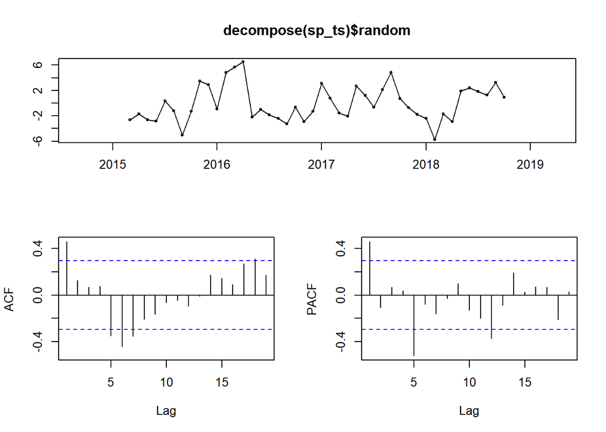

```r
tsdisplay(decompose(sp_ts)$random)
```

O gráfico mostrou um claro efeito sazonal

```r
sarimaModel <- auto.arima(sp_ts, d = 1)
summary(sarimaModel)
```

```
## Series: sp_ts
## ARIMA(0,1,0)(0,1,1)[12]
##
## Coefficients:
##          sma1
##       -0.5778
## s.e.   0.2317
##
## sigma^2 estimated as 26.39:  log likelihood=-133.27
## AIC=270.54   AICc=270.84   BIC=274.06
##
## Training set error measures:
##                     ME     RMSE      MAE       MPE     MAPE      MASE
## Training set 0.4441742 4.448999 2.837193 -4.238814 36.85746 0.6434871
##                    ACF1
## Training set -0.1015661
```

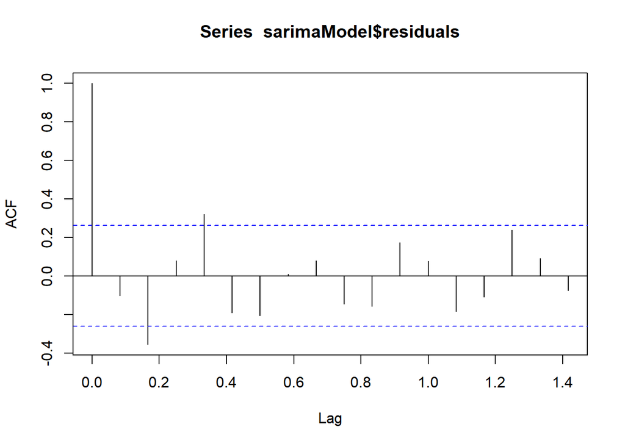

```r
acf(sarimaModel$residuals)
```

A ACF dos resíduos do modelo mostra que a maior parte das autocorrelações estão dentro dos limites. Assim, o modelo ainda pode ser utilizado para a previsão, mas os intervalos preditos podem não ser muito acurados

Fazendo a previsão do modelo e plotando

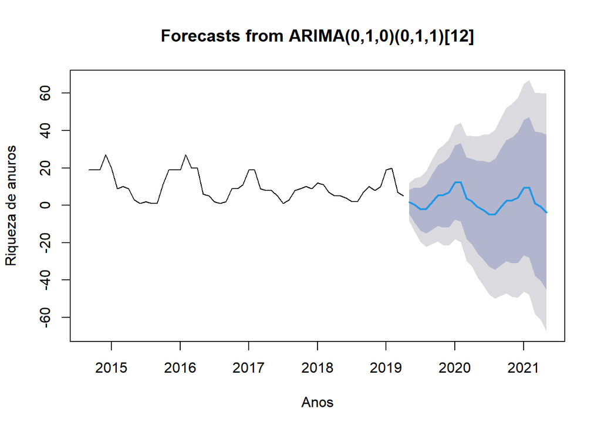

```r
sarima<-forecast(sarimaModel, h=25)
plot(sarima, ylab="Riqueza de anuros", xlab="Anos")
```

Aqui está a previsão para os anos seguintes, onde a parte em azul reflete os intervalos de previsão de 80% e 95%.

# ANÁLISES UNIVARIADAS

Vamos imaginar que temos dados de composição de uma comunidade de anuros e também dados abióticos, temperatura, precipitação e umidade, coletados mensalmente durante um ano. A partir disso queremos investigar se a composição da comunidade de anuros (riqueza e abundância) é influenciada pelas variáveis abióticas locais. Vamos começar!

Importando os dados de demonstração

```r
dados<-read.table("data.txt", header=T) #composição de espécies de uma comunidade de anuros no Parque Estadual da Serra Furada, SC.
dados
```

```
##    mes precipitacao temperatura umidade abundancia riqueza
## 1    1         1.56       13.92   82.60         10      11
## 2    2         3.36       19.76   83.00         20       9
## 3    3         2.04       23.34   76.86         22       8
## 4    4         2.84       21.78   79.00         15      11
## 5    5        15.40       25.24   84.66         20      11
## 6    6        10.52       26.66   77.20         33       6
## 7    7        12.84       24.22   85.80         14       5
## 8    8         0.64       24.32   85.40          3       3
## 9    9         8.00       22.36   87.26          6       6
## 10  10         5.84       18.16   86.93          0       4
## 11  11         0.16       15.60   82.00          2       6
## 12  12         6.28       16.32   90.60          1       5
```

Antes de realizar as análises para verificar a influência das variáveis preditoras sobre a riqueza ou abundância dos anuros precisamos padronizar os dados, pois dados de precipitação, temperatura e umidade possuem diferentes unidades de medida (C°, %, mm). dados_pad = dados padronizados

```r
dados_pad <- decostand(dados[,c(2,3,4)], "standardize")
```

Começaremos as análises dos nossos dados verificando o principal pressuposto estatístico: a normalidade da nossa variável resposta (se possui a curva em forma de sino), que nesse caso será a abundância e riqueza dos anuros

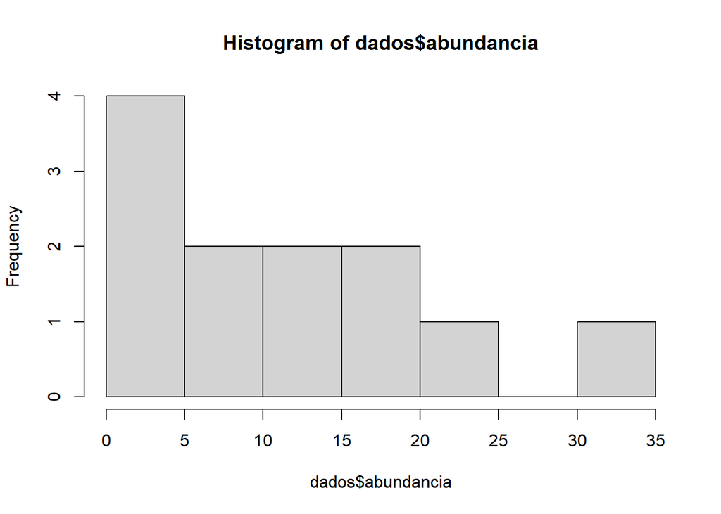

```r
hist(dados$abundancia) #verificando visualmente
```

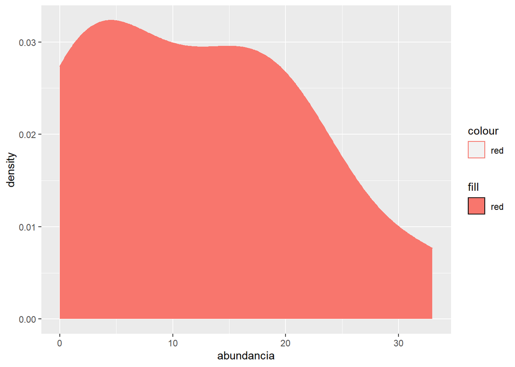

```r
ggplot(dados, aes(abundancia))+
  geom_density(aes(fill="red", col="red"))
```

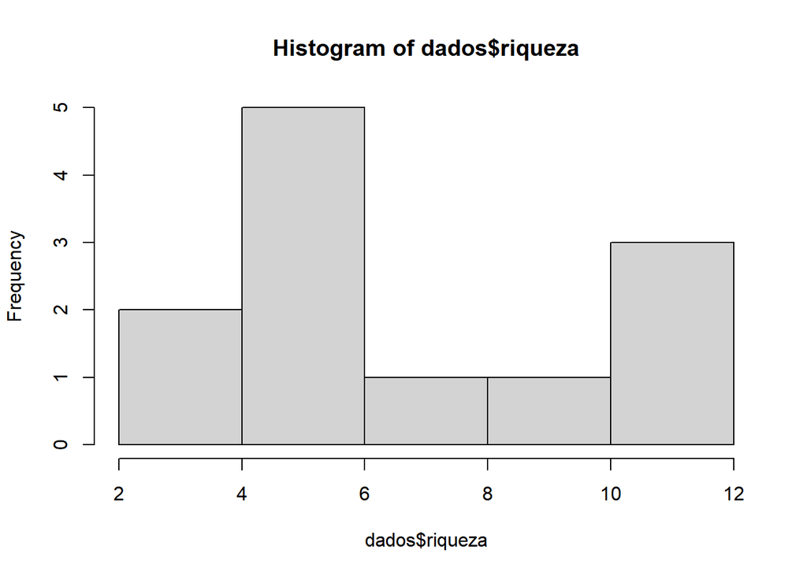

```r
hist(dados$riqueza)
```

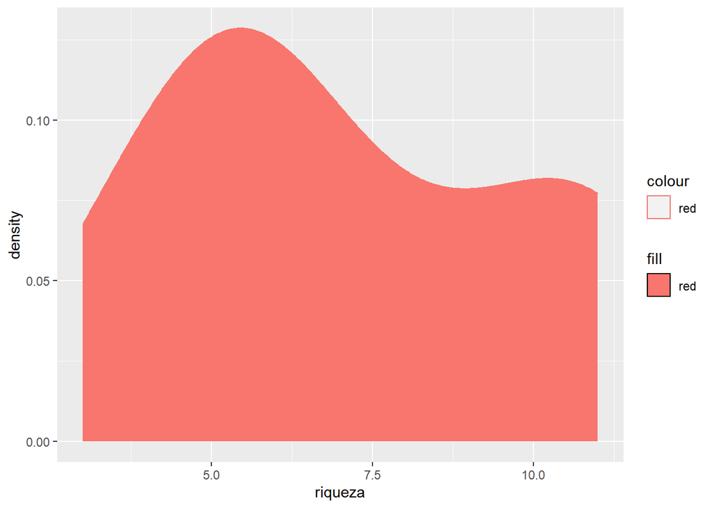

```r
ggplot(dados, aes(riqueza))+
  geom_density(aes(fill="red", col="red"))
```

Podemos também verificar visualmente com o ggpairs

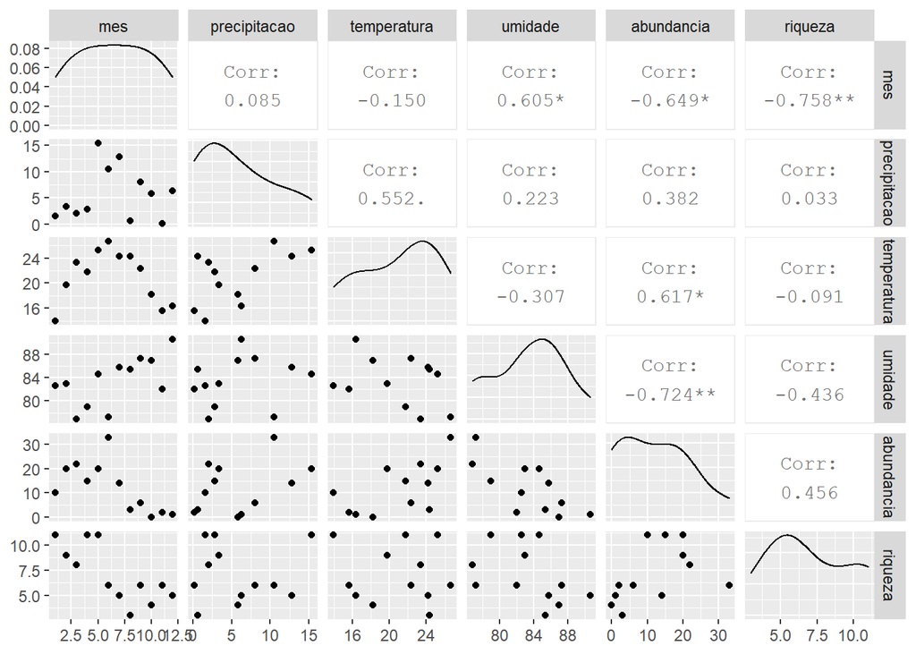

```r
ggpairs(dados)
```

Ele nos dá uma panomara geral dos nossos dados, incluindo a correlação entre as variáveis

Nossos dados não apresentam distribuíção normal, neste caso temos que aplicar um testes NÃO-PARAMÉTRICO (veja a FIG. 1 do manuscrito)

Vamos começar realizando uma **CORRELAÇÃO DE SPEARMAN**. Os valores das correlações variam entre -1 e 1. A correlação de 1 indica uma associação linear positiva entre as variáveis (quando uma variável aumenta a outra aumenta na mesma direção) a correlação de -1 indica uma perfeita associação linear negativa (quando uma variável aumenta a outra diminui)

Vamos testar a correlação entre abundância dos anuros e a precipitação durante 12 meses.

```r
cor.test(dados_pad$precipitacao,dados$abundancia,  method = "spearm")
```

```
##
##  Spearman's rank correlation rho
##
## data:  dados_pad$precipitacao and dados$abundancia
## S = 201.85, p-value = 0.3533
## alternative hypothesis: true rho is not equal to 0
## sample estimates:
##       rho
## 0.2942211
```

*P* não significativo (p>0.05), ou seja, não há uma correlação entre as variáveis

Vamos testar agora a correlação entre abundância dos anuros e a temperatura

```r
cor.test(dados_pad$temperatura, dados$abundancia, method = "spearm")
```

```
##
##  Spearman's rank correlation rho
##
## data:  dados_pad$temperatura and dados$abundancia
## S = 115.7, p-value = 0.04107
## alternative hypothesis: true rho is not equal to 0
## sample estimates:
##       rho
## 0.5954475
```

*P* significativo (p = 0.04), ou seja, há uma correlação entre as variáveis coeficiente (rho) = 0.59, ou seja, correlação positiva.

Agora vamos visualizar essa relação:

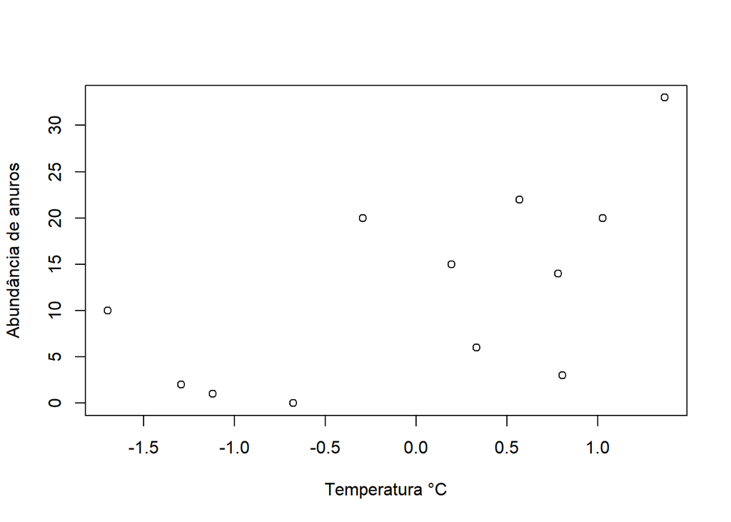

```r
plot(dados_pad$temperatura, dados$abundancia, xlab = "Temperatura °C", ylab = "Abundância de anuros")
```

Veja que há uma tendência do aumento da abundância dos anuros (eixo Y) em função da temperatura (eixo X)

Agora vamos importar dados hipotéticos para o cálculo de uma correlação com dados normalizados, com um teste **PARAMÉTRICO**

```r
dados_normal<-read.table("normal.txt", header=T)
dados_normal
```

```
##    mes precipitacao temperatura umidade abundancia
## 1    1         1.56       13.92   82.60         30
## 2    2         3.36       19.76   83.00         35
## 3    3         2.04       23.34   76.86         31
## 4    4         2.84       21.78   79.00         28
## 5    5        15.40       25.24   84.00         31
## 6    6        10.52       26.66   77.20         70
## 7    7        12.84       24.22   85.00         31
## 8    8         0.64       24.32   85.40         35
## 9    9         8.00       22.36   87.26         30
## 10  10         5.84       18.16   86.93         21
## 11  11         0.16       15.60   82.00         18
## 12  12         6.28       16.32   90.60         27
```

Vamos testar novamente a normalidade dos dados

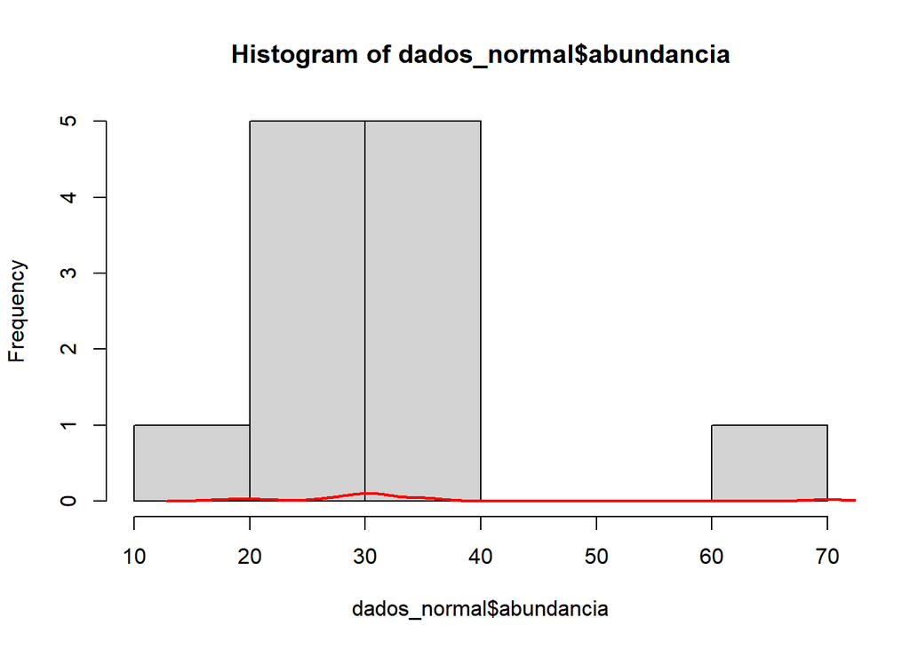

```r
hist(dados_normal$abundancia)
lines(density(dados_normal$abundancia),col="red",lwd=2)
```

Agora sim, estamos trabalhando com dados normalizados

```r
cor.test(dados_normal$temperatura, dados_normal$abundancia, method = "pearson")
```

```
##
##  Pearson's product-moment correlation
##
## data:  dados_normal$temperatura and dados_normal$abundancia
## t = 2.3325, df = 10, p-value = 0.04187
## alternative hypothesis: true correlation is not equal to 0
## 95 percent confidence interval:
##  0.02988115 0.87083692
## sample estimates:
##       cor
## 0.5936032
```

Há correlação, Coeficiente (r) = 0.59, ou seja, correlação positiva.

**No entanto, como você leu no artigo, a correlação não é recomendada para dados com autocorrelação temporal, ou seja, dados que não possuem dependência temporal entre si**

Para lidar com isso, vamos utilizar uma **REGRESSÃO**

Vamos visualizar a relação entre a abundância dos anuros e a temperatura

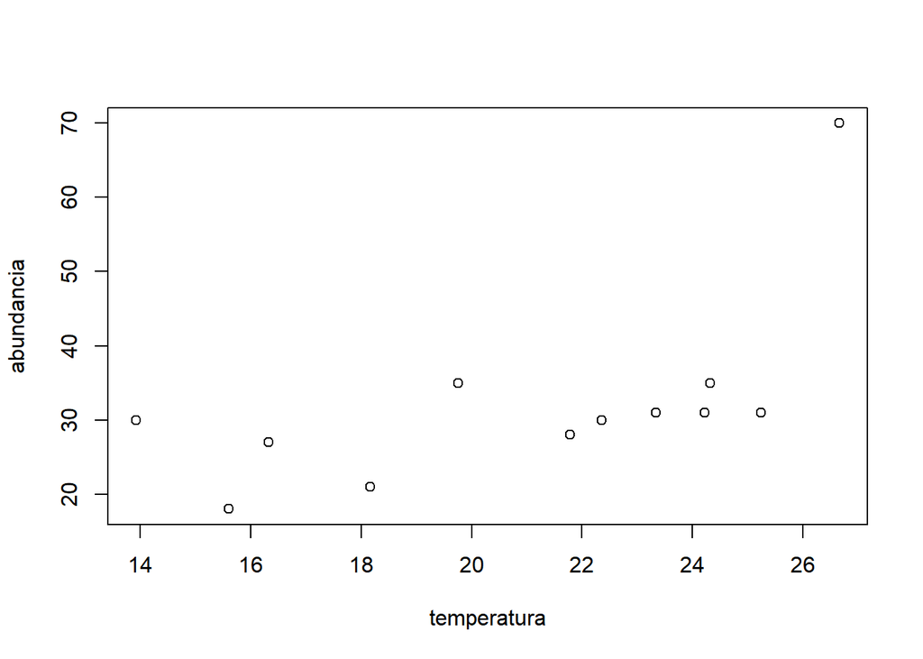

```r
plot(abundancia ~ temperatura,data=dados_normal)
```

Criaremos um modelo simples (linear) para iniciar

```r
mod.ols <- lm(abundancia ~ temperatura,data=dados_normal)
summary(mod.ols)
```

```
##
## Call:
## lm(formula = abundancia ~ temperatura, data = dados_normal)
##
## Residuals:
##    Min     1Q Median     3Q    Max
## -9.108 -5.819 -4.579  3.736 27.276
##
## Coefficients:
##             Estimate Std. Error t value Pr(>|t|)
## (Intercept)  -6.3781    16.8561  -0.378   0.7131
## temperatura   1.8418     0.7896   2.333   0.0419 *
## ---
## Signif. codes:  0 '***' 0.001 '**' 0.01 '*' 0.05 '.' 0.1 ' ' 1
##
## Residual standard error: 10.89 on 10 degrees of freedom
## Multiple R-squared:  0.3524, Adjusted R-squared:  0.2876
## F-statistic: 5.441 on 1 and 10 DF,  p-value: 0.04187
```

Ele indica que há relação entre as variáveis

No entanto, vamos checar os resíduos da regressão para ser se o modelo está adequado com nossos dados

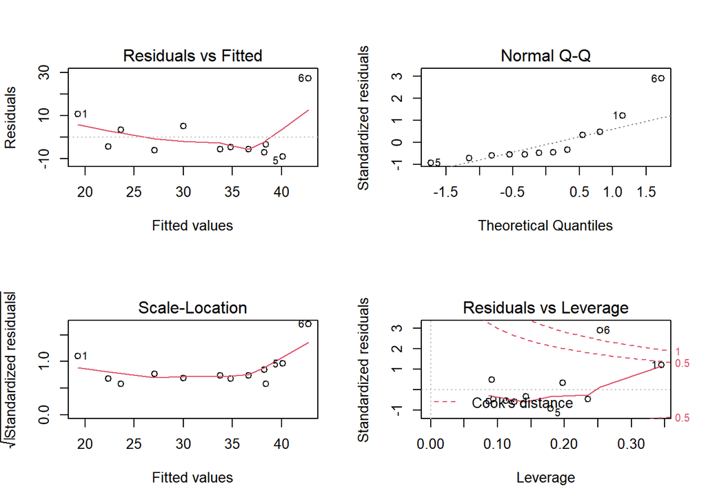

```r
par(mfrow=c(2,2))
plot(mod.ols)
```

```r
par(mfrow=c(1,1))
```

Vamos realizar um teste para ter certeza

```r
dwtest(mod.ols, alternative="two.sided")
```

```
##
##  Durbin-Watson test
##
## data:  mod.ols
## DW = 2.321, p-value = 0.764
## alternative hypothesis: true autocorrelation is not 0
```

# Regressão dos mínimos quadrados generalizados (GLS)

Vamos criar um GLS sem incluir nenhuma estrutura de correlação, que é basicamente a regressão linear feita anteriormente

```r
mod.gls <- gls(abundancia ~ temperatura, data=dados_normal)
```

Agora um modelo GLS indicando que nossos dados são distribuídos temporalmente. Lembrando que o GLS é utilizado apenas com dados contínuos (distribuição Gaussiana). Vamos considerar neste exemplo que os dados de abundância representeam a *altura de empoleiramento de lagartos* em uma floresta. Aqui indicamos a variável (mês das coletas), indicando que os dados são correlacionados temporalmente e que a lag são os meses

```r
mod.gls1 <- gls(abundancia ~ temperatura, data=dados_normal, correlation=corAR1(form=~mes))
```

Você pode testar as várias opcões de correlações existentes nesta função. Veja o help da função para maiores detalhes

```r
?gls
```

Vamos criar outro modelo alterando a estrutura de correlação

```r
mod.gls2 <- gls(abundancia ~ temperatura, data=dados_normal, correlation=corARMA(p = 1, q = 1))
```

Agora vamos usar a **seleção de modelos** para ver qual se adequa melhor aos nossos dados

```r
AICctab(mod.gls1, mod.gls2,base=T, weights=T)
```

```
##          AICc  dAICc df weight
## mod.gls1  97.5   0.0 4  0.951
## mod.gls2 103.5   5.9 5  0.049
```

A partir disso, vamos ver se o probelma de autocorrelação temporal foi resolvido através da análise dos resíduos

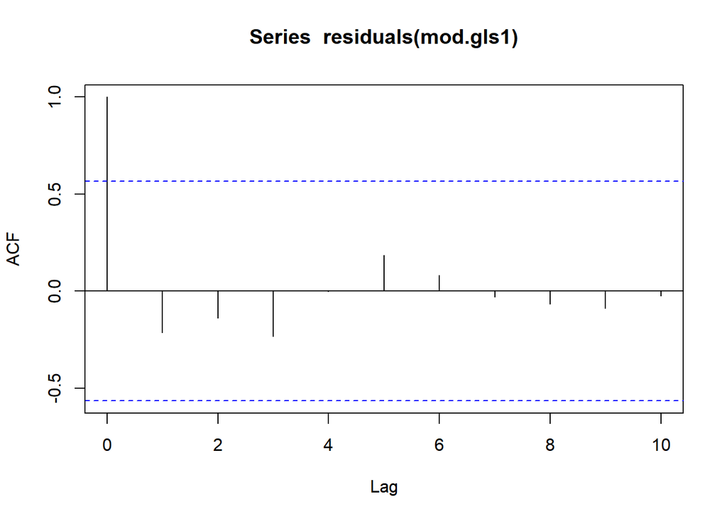

```r
acf(residuals(mod.gls1))
```

Os resíduos ficaram ok, a linha azul significa que apenas uma das médias das autocorrelações excedeu o limite de confiança. No entanto, sem um parâmetro para controlar os efeitos de correlação, as estimativas do modelo não são confiáveis

# GAM (modelos aditivos generalizados)

Vamos iniciar o uso do GAM pelo modelo mais simples e ver se ele resolve o problema de autocorrelação dos resíduos

```r
gam1 <- gam(abundancia ~ temperatura + s(mes), data = dados, family = poisson)
```

Checando o modelo. A função gam.check auxilia a visiualização da distribuição dos redíduos em relação a um preditor linear. Ele ajuda a verificar um dos pressupostos do modelo que é homogeneidade

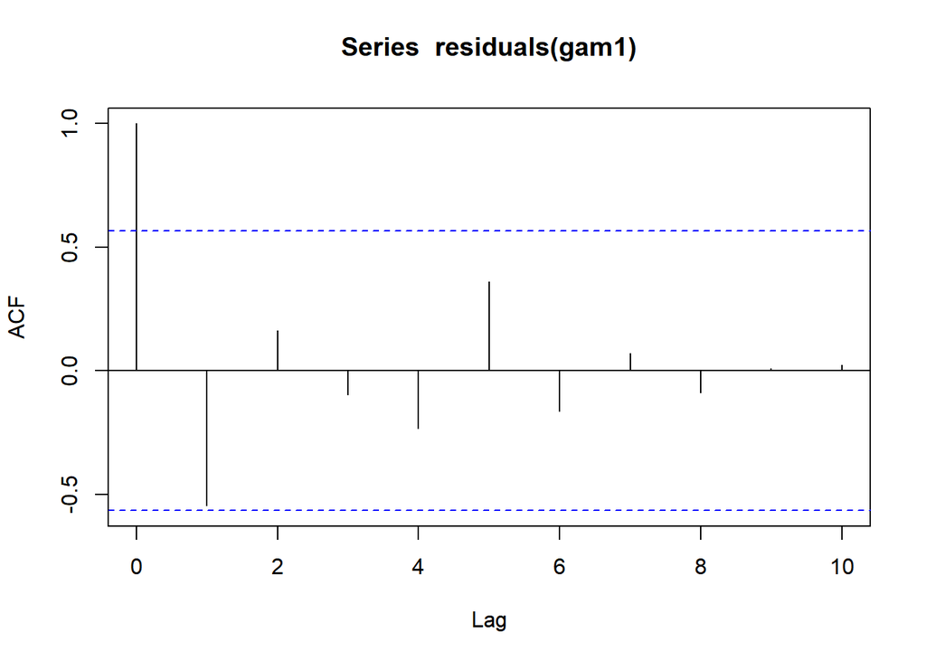

```r
acf(residuals(gam1))
```

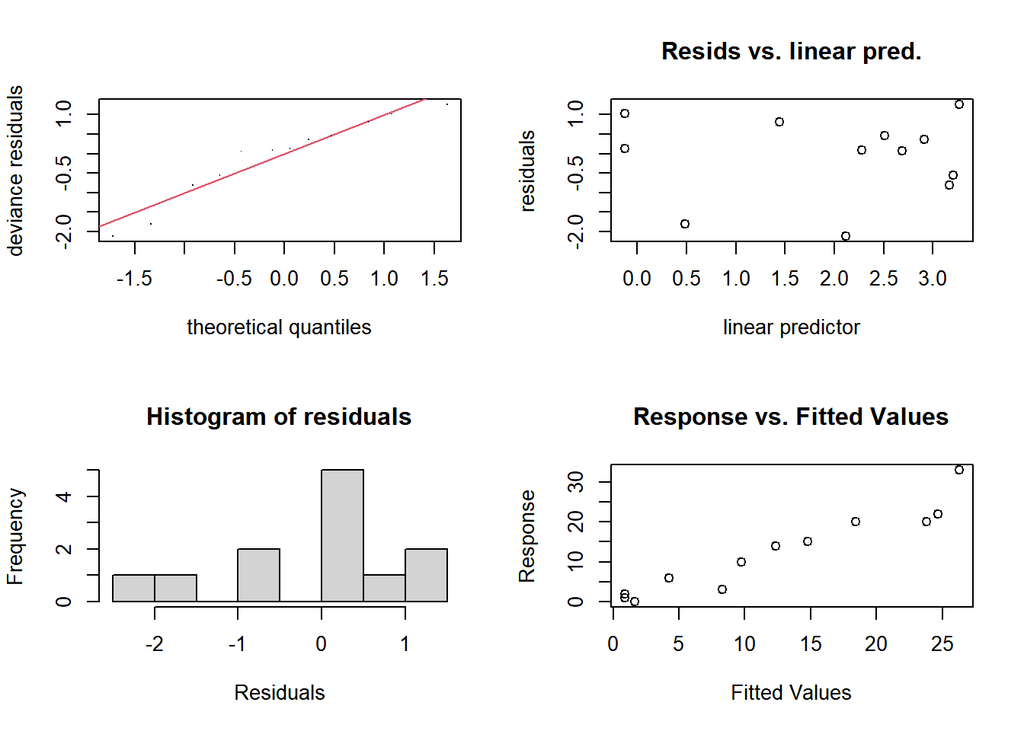

```
##
## Method: UBRE   Optimizer: outer newton
## full convergence after 4 iterations.
## Gradient range [-1.043139e-08,-1.043139e-08]
## (score 0.8975637 & scale 1).
## Hessian positive definite, eigenvalue range [0.0234696,0.0234696].
## Model rank =  11 / 11
##
## Basis dimension (k) checking results. Low p-value (k-index<1) may
## indicate that k is too low, especially if edf is close to k'.
##
##          k'  edf k-index p-value
## s(mes) 9.00 3.23    1.67    0.99
```

```r
gam.check(gam1)
```

Obtendo o resultado do modelo

```r
summary(gam1)
```

```
##
## Family: poisson
## Link function: log
##
## Formula:
## abundancia ~ temperatura + s(mes)
##
## Parametric coefficients:
##             Estimate Std. Error z value Pr(>|z|)
## (Intercept) -1.68699    1.35222  -1.248  0.21219
## temperatura  0.17514    0.06286   2.786  0.00533 **
## ---
## Signif. codes:  0 '***' 0.001 '**' 0.01 '*' 0.05 '.' 0.1 ' ' 1
##
## Approximate significance of smooth terms:
##          edf Ref.df Chi.sq  p-value
## s(mes) 3.227   4.15  39.19 1.61e-07 ***
## ---
## Signif. codes:  0 '***' 0.001 '**' 0.01 '*' 0.05 '.' 0.1 ' ' 1
##
## R-sq.(adj) =  0.851   Deviance explained = 88.7%
## UBRE = 0.89756  Scale est. = 1         n = 12
```

Vamos ver se com um modelo misto que controla variáveis de correlação, os resíduos melhoram

## GAMM (modelos aditivos generalizados mistos)

Para dados com variável resposta em prorporção ou contagem. Aqui utilizaremos os mesmos dados de abundância dos anuros e a temperatura de cada local amostrado ao longo do ano.

Criando o modelo

```r
gamm1 <- gamm(abundancia ~ temperatura + s(mes),data = dados, family = poisson)
```

```
##
##  Maximum number of PQL iterations:  20
```

Note que este modelo possui dois novos argumentos (*s* e *family*). O *s* é o *smooth*, onde indicamos que nossa variável resposta está relacionada com esta outra variável, no caso o mês. No *family* indicamos o tipo dos nossos dados. Nossa variável resposta é dado de contagem (abundância) então nesse caso a familia indicada é Poisson.

Vamos checar os resíduos da regressão para ver se há ainda indícios de autocorrelação dos dados

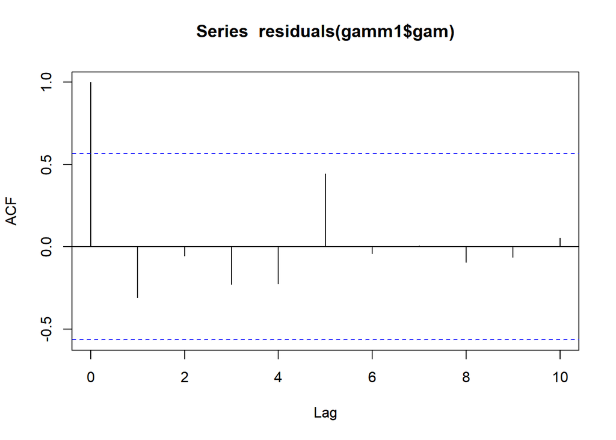

```r
acf(residuals(gamm1$gam))
```

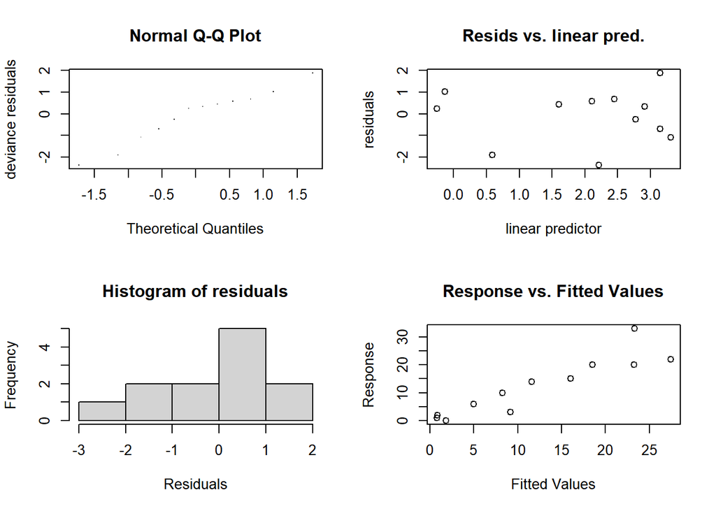

```
##
## 'gamm' based fit - care required with interpretation.
## Checks based on working residuals may be misleading.
## Basis dimension (k) checking results. Low p-value (k-index<1) may
## indicate that k is too low, especially if edf is close to k'.
##
##        k' edf k-index p-value
## s(mes)  9   1     1.4    0.90
```

```r
gam.check(gamm1$gam)
```

Os resíduos estão ok, mas vamos ver se podemos melhorar eles

Obtendo o resultado do modelo

```r
summary(gamm1$gam, cor = FALSE)
```

```
##
## Family: poisson
## Link function: log
##
## Formula:
## abundancia ~ temperatura + s(mes)
##
## Parametric coefficients:
##             Estimate Std. Error t value Pr(>|t|)
## (Intercept) -1.81602    0.78435  -2.315 0.045837 *
## temperatura  0.18146    0.03211   5.652 0.000313 ***
## ---
## Signif. codes:  0 '***' 0.001 '**' 0.01 '*' 0.05 '.' 0.1 ' ' 1
##
## Approximate significance of smooth terms:
##        edf Ref.df     F  p-value
## s(mes)   1      1 32.01 0.000183 ***
## ---
## Signif. codes:  0 '***' 0.001 '**' 0.01 '*' 0.05 '.' 0.1 ' ' 1
##
## R-sq.(adj) =  0.802
##   Scale est. = 1         n = 12
```

A abundância é influenciada pela temperatura e nossa variável smooth teve relação com a variável resposta

Vamos tentar aprimorar nosso modelo gamm usando uma estrutura de correlação

```r
gamm2 <- gamm(abundancia ~ temperatura+ s(mes), data=dados, correlation=corAR1(form=~mes), family = poisson)
```

```
##
##  Maximum number of PQL iterations:  20
```

Aqui também indicamos o modelo de correlação, assim como no gls

Checando os resíduos

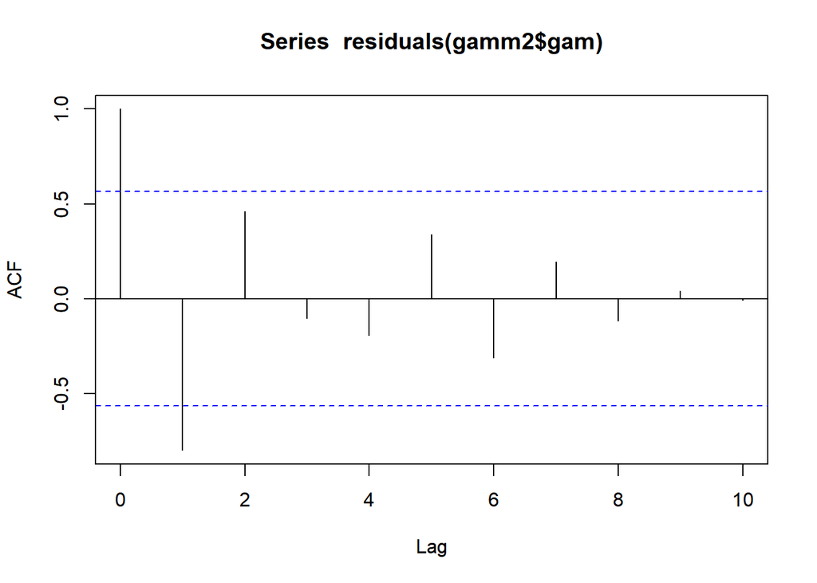

```r
acf(residuals(gamm2$gam))
```

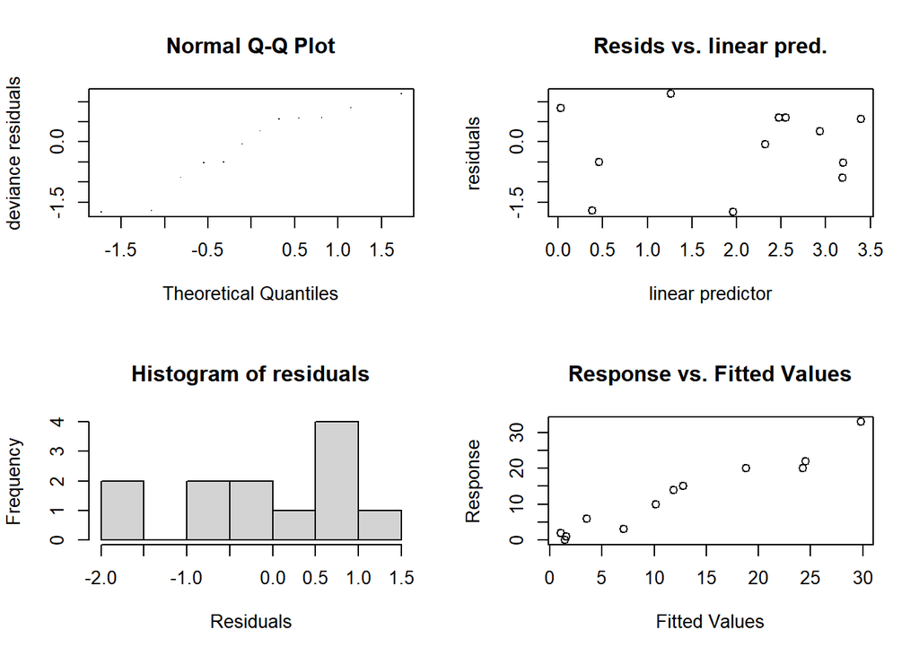

```
##
## 'gamm' based fit - care required with interpretation.
## Checks based on working residuals may be misleading.
## Basis dimension (k) checking results. Low p-value (k-index<1) may
## indicate that k is too low, especially if edf is close to k'.
##
##          k'  edf k-index p-value
## s(mes) 9.00 4.56    1.93       1
```

```r
gam.check(gamm2$gam)
```

Será que este modelo é o mais adequado para nossos dados?

```r
summary(gamm2$gam, cor = FALSE)
```

```
##
## Family: poisson
## Link function: log
##
## Formula:
## abundancia ~ temperatura + s(mes)
##
## Parametric coefficients:
##             Estimate Std. Error t value Pr(>|t|)
## (Intercept) -2.43056    1.27999  -1.899    0.111
## temperatura  0.21186    0.06051   3.501    0.015 *
## ---
## Signif. codes:  0 '***' 0.001 '**' 0.01 '*' 0.05 '.' 0.1 ' ' 1
##
## Approximate significance of smooth terms:
##          edf Ref.df     F  p-value
## s(mes) 4.559  4.559 46.41 1.81e-06 ***
## ---
## Signif. codes:  0 '***' 0.001 '**' 0.01 '*' 0.05 '.' 0.1 ' ' 1
##
## R-sq.(adj) =  0.876
##   Scale est. = 1         n = 12
```

Veja que o valor de *p* da regressão aumentou, assim como o valor da influencia do *smooth*

Vamos testar com mais um modelo e ver se os resíduos melhoram.

```r
gamm3 <- gamm(abundancia ~ s(temperatura)+s(mes),
correlation = corARMA(form = ~ mes, p=1, q=1), family = poisson, data=dados)
```

```
##
##  Maximum number of PQL iterations:  20
```

Checando os redíduos

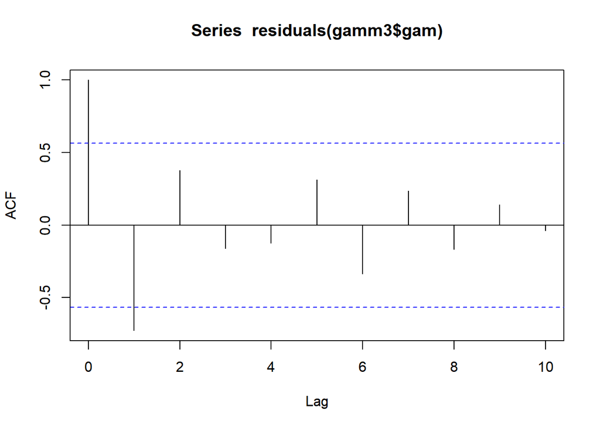

```r
acf(residuals(gamm3$gam))
```

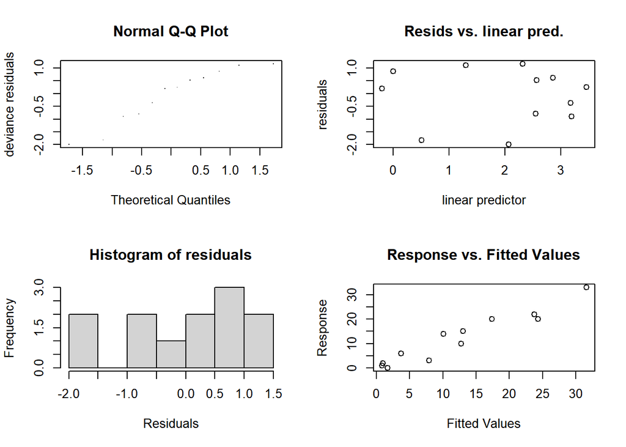

```
##
## 'gamm' based fit - care required with interpretation.
## Checks based on working residuals may be misleading.
## Basis dimension (k) checking results. Low p-value (k-index<1) may
## indicate that k is too low, especially if edf is close to k'.
##
##                 k' edf k-index p-value
## s(temperatura) 9.0 2.5    1.29    0.76
## s(mes)         9.0 1.0    1.84    0.99
```

```r
gam.check(gamm3$gam)
```

Será que ele é o melhor modelo para explicar os dados?

Obtendo o resultado do modelo

```r
summary(gamm3$gam)
```

```
##
## Family: poisson
## Link function: log
##
## Formula:
## abundancia ~ s(temperatura) + s(mes)
##
## Parametric coefficients:
##             Estimate Std. Error t value Pr(>|t|)
## (Intercept)   1.9809     0.0295   67.14 1.06e-11 ***
## ---
## Signif. codes:  0 '***' 0.001 '**' 0.01 '*' 0.05 '.' 0.1 ' ' 1
##
## Approximate significance of smooth terms:
##                  edf Ref.df     F p-value
## s(temperatura) 2.497  2.497 204.8  <2e-16 ***
## s(mes)         1.000  1.000 879.1  <2e-16 ***
## ---
## Signif. codes:  0 '***' 0.001 '**' 0.01 '*' 0.05 '.' 0.1 ' ' 1
##
## R-sq.(adj) =  0.887
##   Scale est. = 1         n = 12
```

Vamos checar isso através do AIC

```r
AICctab(gamm3$lme, gamm2$lme, gamm1$lme, mod.gls1 ,base=T, weights=T)
```

```
##           AICc dAICc df weight
## gamm1$lme 26.1  0.0  4  0.9968
## gamm2$lme 37.6 11.5  5  0.0032
## gamm3$lme 48.4 22.3  7  <0.001
## mod.gls1  97.5 71.4  4  <0.001
```

De acordo com a seleção, o modelo mais adequado é o gamm1! No entanto, temos que lembrar que ele é um modelo misto sem estrutura de correlação, ou seja é semelhante ao GLS. Ele terá resultados mais significativos, mas os valores não são confiáveis. Poderíamos escolher aqui o gamm2 como melhor modelo.

Agora vamos testar mais um pressuposto do modelo com Poisson: a *overdispersion*! Isso acontece quando a variação é maior do que seria esperado (i.e., quando a variância é maior que a média). Ao contrário da distribuição normal, que tem um parâmetro para média e outro para a variância, a distribuição de Poisson tem um parâmetro só – assumindo assim que a média é igual à variância (Zuur et al. 2009). No entanto, isso pode não acontecer. Assim, quando os dados são mais dispersos do que seria esperado numa distribuição de Poisson temos a superdispersão. Quando isso ocorre podemos incluir um parâmetro de variância no modelo (mudar a family para quasipoisson, family=quasipoisson) ou mudar para distribuição binomial negativa (usando a função glm.nb do pacote MASS). A distribuição binomial negativa permite modelar a variância separadamente da média utilizando dois parâmetros diferentes, fazendo com que a variância possa ser maior do que a média (Zuur et al. 2009).

Se o valor for 0, o modelo não apresenta *overdispersion*

```r
e1<-resid(gamm2, typpe="pearson")
overdispersion<-sum(e1^2)/gamm2$gam$df.residual
overdispersion
```

```
## [1] 0
```

Pronto!

# ESTATÍSTICA CIRCULAR TESTE DE RAYLEIGH

Esse teste tem a premissa da normalidade de *Von Mises*

```r
watson.test(dados$riqueza, dist="vonmises")
```

```
##
##        Watson's Test for the von Mises Distribution
##
## Test Statistic: 0.0592
## P-value > 0.10
##
```

Os dados apresentam a distribuição normal de *Von Mises*

Agora vamos transformar nossos dados de riqueza em um objeto circular

```r
x <- circular(dados$riqueza)
print(x)
```

```
## Circular Data:
## Type = angles
## Units = radians
## Template = none
## Modulo = asis
## Zero = 0
## Rotation = counter
##  [1] 11  9  8 11 11  6  5  3  6  4  6  5
```

Fazendo o teste de Rayleigh para ver se nossos dados de riqueza apresentam um padrão sazonal

```r
rayleigh.test(x, mu = NULL)
```

```
##
##        Rayleigh Test of Uniformity
##        General Unimodal Alternative
##
## Test Statistic:  0.419
## P-value:  0.1211
```

A riqueza de anuros não apresenta um padrão sazonal

Vamos ver isso com a ajuda de um gráfico

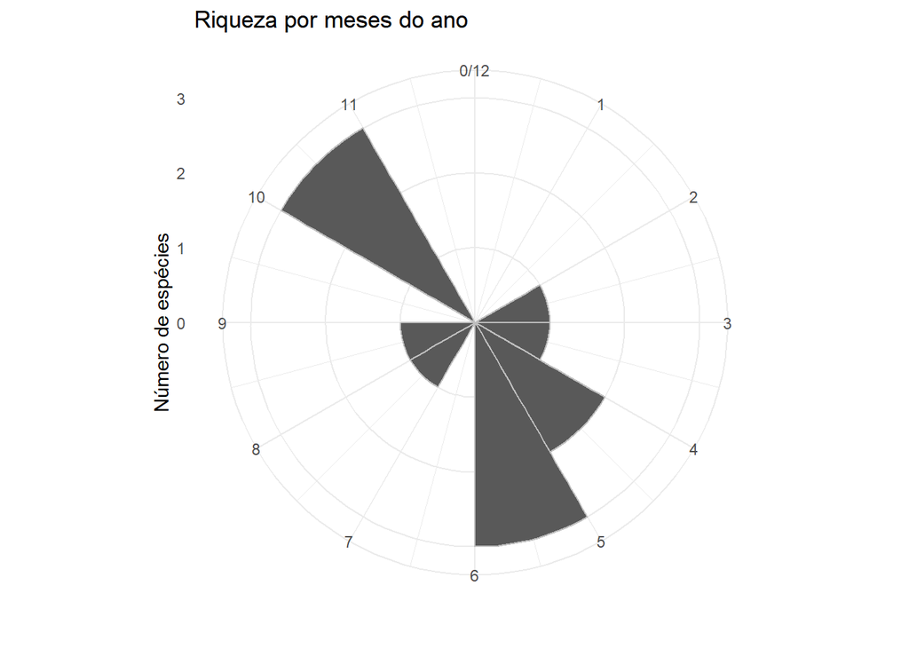

```r
ggplot(dados, aes(x = riqueza, fill = riqueza)) +
  geom_histogram(breaks = seq(0,  12), colour = "grey") +
  coord_polar(start = 0) + theme_minimal() +
  scale_fill_brewer() + ylab("Número de espécies") +
  ggtitle("Riqueza por meses do ano") +
  scale_x_continuous("", limits = c(0, 12), breaks = seq(0, 12), labels = seq(0,12))
```

Agora vamos criar um vetor circular

```r
y <- rvonmises(n=25, mu=circular(pi), kappa=2)
```

E realizar o mesmo teste

```r
rayleigh.test(y, mu = NULL)
```

```
##
##        Rayleigh Test of Uniformity
##        General Unimodal Alternative
##
## Test Statistic:  0.7089
## P-value:  0
```

O valor de *p* foi 0, indicando que os dados estão distribuídos de forma sazonal

Criando uma imagem simples desta relação

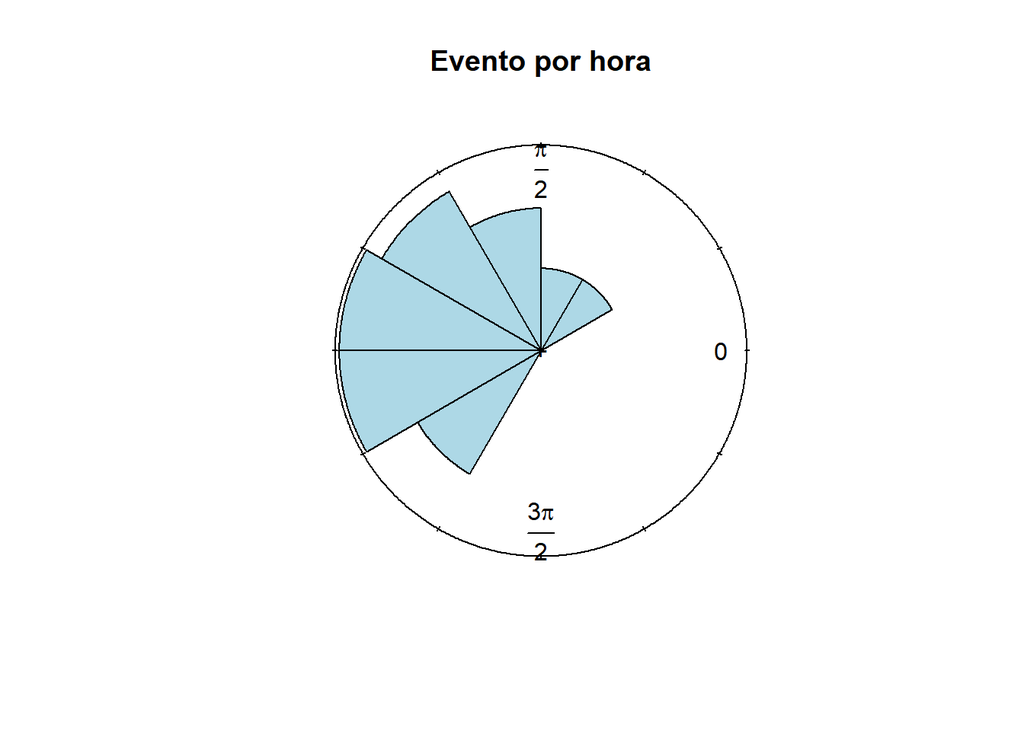

```r
rose.diag(y, bin = 12, col = "lightblue", main = "Evento por hora",
    prop = 2, axes = T)
```

# MÉTODOS MULTIVARIADOS

## Space-time interaction (Legendre et al. 2010)

Carregando dados de abundância de uma metacomunidade de anuros (Ceron et al. 2020)

```r
spi <- read.table("spatio_temporal.txt", h=TRUE)
head(spi)
```

```
##           Site month Aer Ape Bhy Dbe Dna Ebi Ffi Hme Bbi Bfa Bma Ihe Aar Lgr
## 1 stream_north     1   0   0   0   0   0   0   0   0   0   0   1   2   0   0
## 2  marsh_north     1   0   0   0   0   4   0   0   0   2   0   2   0   0   0
## 3 forest_north     1   0   0   0   0   0   0   0   0   0   0   0   0   0   0
## 4 stream_south     1   0   0   0   0   0   0   0   0   0   0   0   0   0   0
## 5  marsh_south     1   0   0   0   0   0   0   0   0   0   0   0   0   0   0
## 6 forest_south     1   0   0   0   1   0   0   0   0   1   0   0  10   0   0
##   Lla Lpl Pdi Pna Pbo Rab Ric Oca Sfu Sgr Spe Tme Vur
## 1   0   0   0   0   0   0   0   0   0   0   0   0   0
## 2   1   1   0   0   0   4   2   0   0   2   5   0   0
## 3   0   0   0   0   0   0   0   0   0   0   0   0   0
## 4   0   0   0   0   0   0   0   0   0   0   0   0   0
## 5   0   0   0   0   0   0   0   0   0   0   0   0   0
## 6   0   0   0   0   0   0   0   0   0   0   0   0   0
```

Transformando os dados de abundancia utilizando Hellinger para diminuir a diferença entre as espécies

```r
spi.std <- decostand(spi[,-c(1,2)], "hell")
head(spi.std)
```

```
##   Aer Ape Bhy       Dbe       Dna Ebi Ffi Hme       Bbi Bfa       Bma       Ihe
## 1   0   0   0 0.0000000 0.0000000   0   0   0 0.0000000   0 0.5773503 0.8164966
## 2   0   0   0 0.0000000 0.4170288   0   0   0 0.2948839   0 0.2948839 0.0000000
## 3   0   0   0 0.0000000 0.0000000   0   0   0 0.0000000   0 0.0000000 0.0000000
## 4   0   0   0 0.0000000 0.0000000   0   0   0 0.0000000   0 0.0000000 0.0000000
## 5   0   0   0 0.0000000 0.0000000   0   0   0 0.0000000   0 0.0000000 0.0000000
## 6   0   0   0 0.2886751 0.0000000   0   0   0 0.2886751   0 0.0000000 0.9128709
##   Aar Lgr       Lla       Lpl Pdi Pna Pbo       Rab       Ric Oca Sfu       Sgr
## 1   0   0 0.0000000 0.0000000   0   0   0 0.0000000 0.0000000   0   0 0.0000000
## 2   0   0 0.2085144 0.2085144   0   0   0 0.4170288 0.2948839   0   0 0.2948839
## 3   0   0 0.0000000 0.0000000   0   0   0 0.0000000 0.0000000   0   0 0.0000000
## 4   0   0 0.0000000 0.0000000   0   0   0 0.0000000 0.0000000   0   0 0.0000000
## 5   0   0 0.0000000 0.0000000   0   0   0 0.0000000 0.0000000   0   0 0.0000000
## 6   0   0 0.0000000 0.0000000   0   0   0 0.0000000 0.0000000   0   0 0.0000000
##         Spe Tme Vur
## 1 0.0000000   0   0
## 2 0.4662524   0   0
## 3 0.0000000   0   0
## 4 0.0000000   0   0
## 5 0.0000000   0   0
## 6 0.0000000   0   0
```

```r
dim(spi.std)
```

```
## [1] 72 27
```

Rodando a análise STI. *S* é o número de áreas amostradas e *Ti* é o número de campanhas amostrais

```r
stimodels(spi.std, S=6, Ti=12)
```

```
## =======================================================
##         Space-time ANOVA without replicates
##
##   Pierre Legendre, Miquel De Caceres, Daniel Borcard
## =======================================================
##
##  Number of space points (s) = 6
##  Number of time points (tt) = 12
##  Number of observations (n = s*tt) = 72
##  Number of response variables (p) = 27
##
##  Computing dbMEMs to code for space
##  Truncation level for space dbMEMs = 1
##  Computing dbMEMs to code for time
##  Truncation level for time dbMEMs = 1
##
##  Number of space coding functions = 2
##
##  Number of time coding functions = 5
##
##  MODEL V: HELMERT CONTRAST FOR TESTING MAIN FACTORS.
##           SPACE AND TIME dbMEMs FOR TESTING INTERACTION.
##    Number of space variables = 5
##    Number of time variables = 11
##    Number of interaction variables = 10
##    Number of residual degrees of freedom = 45
##
##  Interaction test:   R2 = 0.1421   F = 1.5461   P( 999 perm) = 0.002
##  Space test:         R2 = 0.2776   F = 6.041   P( 999 perm) = 0.001
##  Time test:          R2 = 0.1668   F = 1.6499   P( 999 perm) = 0.001
## -------------------------------------------------------
##       Time for this computation = 1.630000  sec
## =======================================================
```

## STATICO

Carregando os dados da composição da comunidade (espécies por locais), variáveis ambientais (locais por variáveis) e uma matriz indicando como as unidades amostrais estão arranjadas nas estações do ano. Dados obtidos em Ceron et al. (2020).

```r
design <- read.table("design.txt", h=TRUE)
head(design)
```

```
##      site season
## nw1 north winter
## sw1 south winter
## ns1 north winter
## ss1 south winter
## ns2 north spring
## ss2 south spring
```

```r
spe <- read.table("spatio.txt", h=TRUE)
head(spe)
```

```
##    Site month Aer Ape Bhy Dbe Dna Ebi Ffi Hme Bbi Bfa Bma Ihe Aar Lgr Lla Lpl
## 1 north     1   0   0   0   0   4   0   0   0   2   0   3   2   0   0   1   1
## 2 south     1   0   0   0   1   0   0   0   0   1   0   0  10   0   0   0   0
## 3 north     2   0   0   3   0   0   0   6   0   1   0   7   2   0   0   0   7
## 4 south     2   5   0   2   1   0   0  45   2   9   1   0   0   0   0   0   0
## 5 north     3   0   4   0   0   0   0   8   0   1   0   5   0   0   0   0   0
## 6 south     3   5   0   3   0   0   0  30   0  10   0   0   9   3   0   0   0
##   Pdi Pna Pbo Rab Ric Oca Sfu Sgr Spe Tme Vur
## 1   0   0   0   4   2   0   0   2   5   0   0
## 2   0   0   0   0   0   0   0   0   0   0   0
## 3   0   0   0   0   4   0   0   0   3   0   0
## 4   0  10   1   0   0   0   0   0   1   0   1
## 5   0   0   8   0   9   0   1   0   1   0   0
## 6   0   8   1   0   0   0   0   0   1   0   8
```

```r
spe <- spe[,-c(1,2)]

env <- read.table("env1.txt", h=TRUE)
head(env)
```

```
##      site   month rain temp   hum photo
## nw1 north  winter  5.8 16.9 95.66 665.4
## sw1 south  winter  0.2 18.6 89.00 666.6
## ns1 north winter1  0.0 19.4 88.00 691.8
## ss1 south winter1  0.2 23.1 69.33 692.4
## ns2 north  spring  1.8 19.7 91.33 744.0
## ss2 south  spring  8.4 22.7 87.33 745.2
```

```r
env <- env[,-c(1,2)]
head(env)
```

```
##     rain temp   hum photo
## nw1  5.8 16.9 95.66 665.4
## sw1  0.2 18.6 89.00 666.6
## ns1  0.0 19.4 88.00 691.8
## ss1  0.2 23.1 69.33 692.4
## ns2  1.8 19.7 91.33 744.0
## ss2  8.4 22.7 87.33 745.2
```

Transformando os dados de abundancia utilizando Hellinger para diminuir a heterogeneidade de abundância entre as espécies

```r
spe_std <- decostand(spe, "hell", MARGIN = 2)
```

Agora vamos iniciar os três passos da análise. Iremos rodar primeiramente uma análise de correspondência na matriz de composição das espécies.

```r
speca <- dudi.coa(spe_std, nf = 2, scan = FALSE)
```

Em seguida, vamos inserir o resultado da CA em uma espécie de PCA

```r
wit22 <- wca(speca, as.factor(design$season), scan = FALSE, nf = 2)
```

Agora, devemos transformar nosso objeto da função anterior em uma tabela-k, ou seja, uma série de tabelas que serão analisadas posteriormente em conjunto

```r
kta22 <- ktab.within(wit22)
spl0 <- split(env, design$season)
spl1 <- split(kta22$cw, design$season)
```

Por fim, iremos preparar os dados para executar a Análise Triádica Parcial, que resume as informações das duas análises multivariadas anteriores

```r
spl2 <- lapply(1:4, function(k) scalewt(spl0[[k]], wt = spl1[[k]], scale = FALSE))
w <- NULL
for (k in 1:4) w <- rbind.data.frame(w, spl2[[k]])
p1 <- apply(w, 2, function(x) sqrt(sum(x*x*kta22$cw)/4))
w <- sweep(w, 2, p1, "/")
apply(w, 2, function(x) sum(x*x*kta22$cw))
```

```
##  rain  temp   hum photo
##     4     4     4     4
```

```r
w <- as.data.frame(t(w))
kta12 <- ktab.data.frame(w, rep(6, 4), tabnames=tab.names(kta22), w.row=rep(1, 4), w.col = kta22$cw)
ktacroi <- ktab.match2ktabs(kta12, kta22)
statico12 <- pta(ktacroi, scan = FALSE)
```

Agora vamos gerar os mapas informativos: O primeiro demonstra a semelhança entre cada par de matrizes e exibe para cada estação/ano/mês a semelhança entre as variáveis ambientais, as espécies e os locais estudados

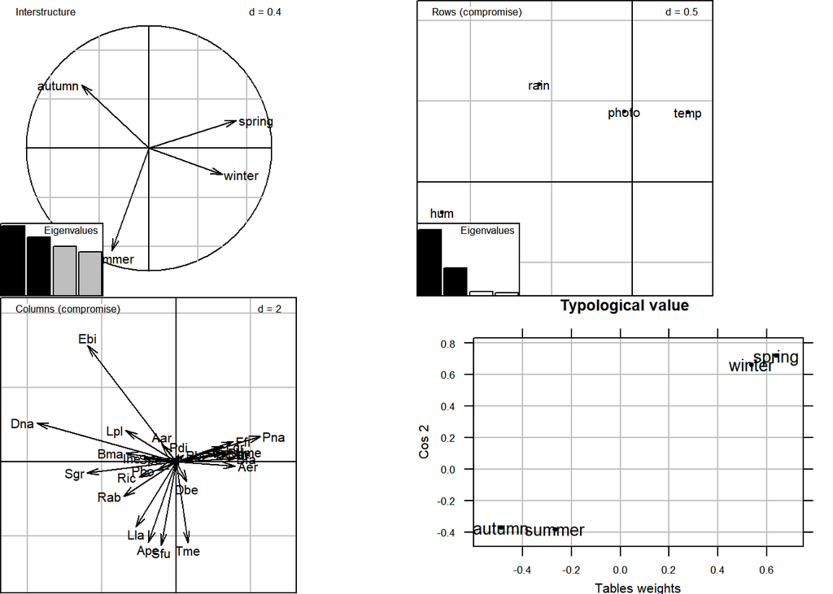

```r
plot(statico12, plabels.boxes.draw = FALSE)
```

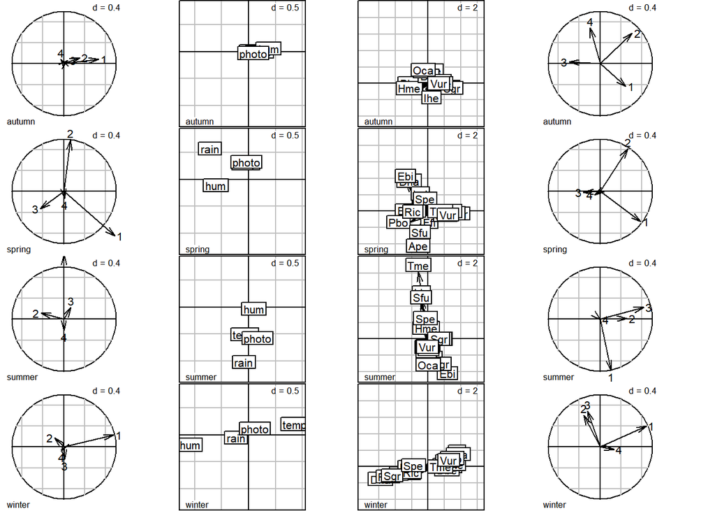

```r
kplot(statico12, plabels.boxes.draw = FALSE)
```

O segundo ilustra a ordenação das variáveis ambientais e das espécies em um espaço reduzido, indicando a relação espaço-ambiente

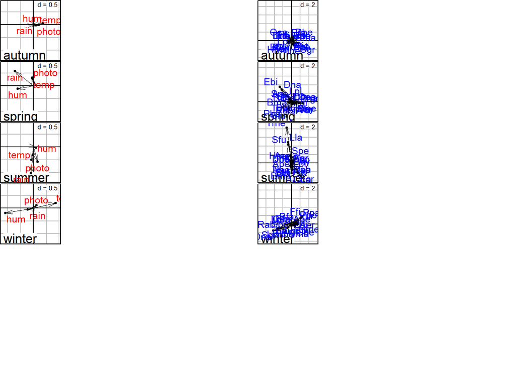

```r
slE <- s.label(statico12$Tli, facets = statico12$TL[, 1], labels = statico12$TL[, 2], psub.cex = 2, plabel=list(col = "red", cex=1.5, optim=TRUE), plot=FALSE)
saE <- s.arrow(statico12$Tli, facets = statico12$TL[, 1], psub.cex = 0, plabels.cex=0, plines.lwd=0.5, plot=FALSE)
sE <- superpose(slE, saE)
slH <- s.label(statico12$Tco, facets = statico12$TC[, 1], labels = statico12$TC[, 2], psub.cex = 2, plabel=list(col = "blue", cex=1.5, optim=TRUE), plot=FALSE)
saH <- s.arrow(statico12$Tco, facets = statico12$TC[, 1], psub.cex = 0, plabel.cex=0, plines.lwd=0.5, plot=FALSE)
sH <- superpose(slH, saH)
sE1 <- sE[1:4]
sH1 <- sH[1:4]
sE1@positions <- layout2position(c(6,1))
sH1@positions <- layout2position(c(6,1))
sEH1 <- ADEgS(list(sE1, sH1), layout=c(1,2))
```

E o terceiro mapeia a trajetória das espécies e das variáveis ambientais em cada estação/ano/mês a fim de resumir a estrutura das matrizes cruzadas

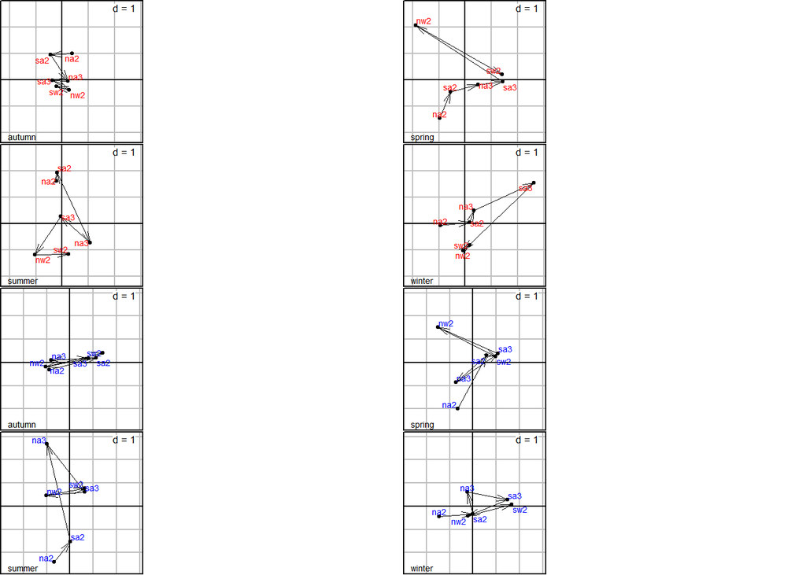

```r
st1 <- s.traject(statico12$supIX, facets=statico12$supTI[,1], plabels.cex=0, plot=FALSE, psub.cex=0, plines.lwd=0.5)
sla1 <- s.label(statico12$supIX, facets=statico12$supTI[,1], plot=FALSE, psub.cex=.8, labels=statico12$supTI[,2], plabels=list(cex=.8, col="red", optim=TRUE))
s1 <- superpose(st1, sla1)
st2 <- s.traject(statico12$supIY, facets=statico12$supTI[,1], plabels.cex=0, plot=FALSE, psub.cex=0, plines.lwd=0.5)
sla2 <- s.label(statico12$supIY, facets=statico12$supTI[,1], plot=FALSE, psub.cex=.8, labels=statico12$supTI[,2], plabels=list(cex=0.8, col="blue", optim=TRUE))
s2 <- superpose(st2, sla2)
ADEgS(list(s1,s2), layout = c(2,1))
```

Para maiores informações em como interpretar os gráficos consulte:

- Slimani, N., Guilbert, E., El Ayni, F., Jrad, A., Boumaiza, M., & Thioulouse, J. (2017). The use of STATICO and COSTATIS, two exploratory threeways analysis methods: An application to the ecology of aquatic heteroptera in the Medjerda watershed (Tunisia). Environmental and Ecological Statistics, 24(2), 269–295. https://doi.org/10.1007/s10651-017-0370-6
- Ceron, K, Santana, DJ, Lucas, EM, Zocche, JJ, Provete, DB. Climatic variables influence the temporal dynamics of an anuran metacommunity in a nonstationary way. Ecol Evol. 2020; in press. https://doi.org/10.1002/ece3.6217
- Kidé, S. O., Manté, C., Dubroca, L., Demarcq, H., & Mérigot, B. (2015). Spatio-temporal dynamics of exploited groundfish species assemblages faced to environmental and fishing forcings: Insights from the mauritanian exclusive economic zone. PLoS ONE, 10, e0141566. https://doi.org/10.1371/journal.pone.0141566